# Chapter4

Julin N Maloof

4/23/2019

4E1-4E5; 4M1, 4M2, 4M3

## 4E1.

*In the model definition below, which line is the likelihood?*

$$y_i \sim Normal(\mu, \sigma)$$

## 4E2.

*In the model definition just above, how many parameters are in the posterior distribution?*

Two, $\mu, \sigma$

## 4E3.

*Using the model definition above, write down the appropriate form of Bayes’ theorem that includes the proper likelihood and priors.*

## 4E4.

*In the model definition below, which line is the linear model?*

$$\mu_i = \alpha + \beta x_i$$

## 4E5.

*In the model definition just above, how many parameters are in the posterior distribution?*

Three, $\alpha, \beta, \sigma$

## 4M1.

*For the model definition below, simulate observed heights from the prior (not the posterior).*

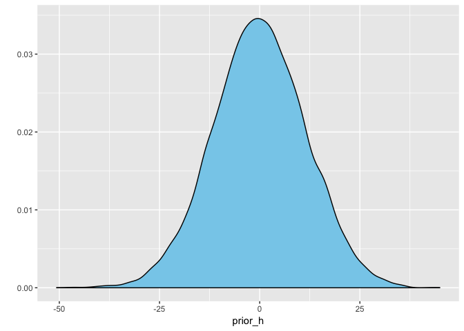

```r
prior_h <- rnorm(n = 10000,
                 mean = rnorm(n = 10000, mean = 0, sd = 10),
                 sd = runif(n = 10000, min = 0, max = 10))

  qplot(prior_h, geom="density", fill=I("skyblue"))
```

## 4M2.

*Translate the model just above into a quap formula.*

```r
f <- alist(
  height ~ dnorm(mu, sigma),
  mu ~ dnorm(0, 10),
  sigma ~ dunif(0, 10))
```

## 4M3.

*Translate the quap model formula below into a mathematical model definition.*

```r
flist <- alist(
    y ~ dnorm( mu , sigma ),
    mu <- a + b*x,
    a ~ dnorm( 0 , 50 ),
    b ~ dunif( 0 , 10 ),
    sigma ~ dunif( 0 , 50 )
)
```

$$y_i \sim Normal (\mu_i, \sigma) \\
mu_i = \alpha + \beta x_i \\
\alpha \sim Normal(0, 50) \\
\beta \sim Uniform(0, 10) \\
\sigma \sim Uniform(0, 50)$$

# Week 2 problems

4M4, 4M5, 4M6, 4H1, 4H2

## 4M4

*A sample of students is measured for height each year for 3 years. After the third year, you want to fit a linear regression predicting height using year as a predictor. Write down the mathematical model definition for this regression, using any variable names and priors you choose. Be prepared to defend your choice of priors.*

$$y_i \sim Normal (\mu_i, \sigma) \\
mu_i = \alpha + \beta*year_i \\
\alpha \sim Normal(100, 50) \\
\beta \sim Log-Normal(0, 1) \\
\sigma \sim Uniform(0, 50)\\$$
Really we should fit each student as a random effect, but we aren’t there yet.

Assume height measured in cm. We don’t know the age of the students but I am assuming elementary age. 100cm with a broad SD.

how much can a student grow in a year? 10cm?

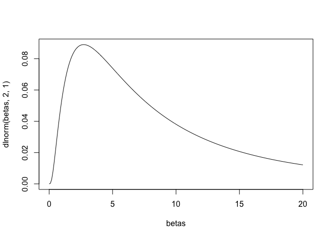

```r
betas <- seq(0,20,by=.1)
plot(betas,dlnorm(betas,2,1),type="l")
```

not entirely happy with this…

## 4M5

*Now suppose I tell you that the average height in the first year was 120 cm and that every student got taller each year. Does this information lead you to change your choice of priors? How?*

Not so different, but I would go with:

$$y_i \sim Normal (\mu_i, \sigma) \\
mu_i = \alpha + \beta*year_i \\
\alpha \sim Normal(120, 50) \\
\beta \sim Log-Normal(0, 1) \\
\sigma \sim Uniform(0, 50)\\$$

## 4M6

*Now suppose I tell you that the variance among heights for students of the same age is never more than 64cm. How does this lead you to revise your priors?*

$$y_i \sim Normal (\mu_i, \sigma) \\
mu_i = \alpha + \beta*year_i \\
\alpha \sim Normal(120, 50) \\
\beta \sim Log-Normal(0, 1) \\
\sigma \sim Uniform(0, 8)\\$$

## 4H1

*The weights listed below were recorded in the !Kung census, but heights were not recorded for these individuals. Provide predicted heights and 89% intervals (either HPDI or PI) for each of these individuals. That is, fill in the table below, using model-based predictions.*

```r
weights <- c(46.95,43.72,64.78,32.59,54.63)
```

These all seem to be adult weights, so I am going to use the simple regression model on adults

```r
#4.42
data(Howell1)
d <- Howell1
d2 <- d[ d$age >= 18 , ]

# define the average weight, x-bar
xbar <- mean(d2$weight)

# fit model
m4.3 <- quap(
    alist(
        height ~ dnorm( mu , sigma ) ,
        mu <- a + b*( weight - xbar ) ,
        a ~ dnorm( 178 , 20 ) ,
        b ~ dlnorm( 0 , 1 ) ,
        sigma ~ dunif( 0 , 50 )
    ) ,
    data=d2 )
```

```r
sim.heights <- sim(fit = m4.3,
                   data = data.frame(weight=weights),
                   n=1e4)
dim(sim.heights)
```

```
## [1] 10000     5
```

```r
head(sim.heights)
```

```
##          [,1]     [,2]     [,3]     [,4]     [,5]
## [1,] 157.4049 158.9164 173.7565 128.4920 162.1303
## [2,] 157.2506 148.4500 178.6658 144.4662 166.7329
## [3,] 151.3772 151.9207 177.6453 142.1428 161.9565
## [4,] 154.3727 158.7349 167.5517 138.1722 164.1422
## [5,] 157.6281 155.2929 164.5594 143.0228 167.9828
## [6,] 156.2978 151.8533 172.9743 144.7207 161.1789
```

```r
results <- tibble(
  individual=1:5,
  weight=weights,
  predicted.height=apply(sim.heights,2,mean)
  )
results <- cbind(results,t(apply(sim.heights, 2, HPDI)))
knitr::kable(results,digits=2)
```

| individual | weight | predicted.height | \|0.89 | 0.89\| |
| --- | --- | --- | --- | --- |
| 1 | 46.95 | 156.37 | 148.39 | 164.56 |
| 2 | 43.72 | 153.37 | 145.55 | 161.62 |
| 3 | 64.78 | 172.48 | 164.37 | 180.74 |
| 4 | 32.59 | 143.38 | 135.09 | 151.35 |
| 5 | 54.63 | 163.30 | 155.50 | 171.90 |

## 4H2.

*Select out all the rows in the Howell1 data with ages below 18 years of age. If you do it right, you should end up with a new data frame with 192 rows in it.*

```r
d3 <- Howell1 %>% as_tibble() %>% filter(age < 18)
d3
```

```
## # A tibble: 192 x 4
##    height weight   age  male
##     <dbl>  <dbl> <dbl> <int>
##  1  122.    19.6  12       1
##  2  105.    13.9   8       0
##  3   86.4   10.5   6.5     0
##  4  130.    23.6  13       1
##  5  109.    16.0   7       0
##  6  137.    27.3  17       1
##  7  126.    22.7  16       0
##  8  114.    17.9  11       1
##  9  145.    28.8  17       0
## 10  122.    20.4   8       1
## # … with 182 more rows
```

*(a) Fit a linear regression to these data, using quap. Present and interpret the estimates. For every 10 units of increase in weight, how much taller does the model predict a child gets?*

first let’s take a look

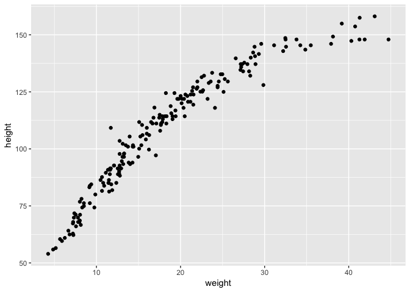

```r
qplot(weight, height, data = d3)
```

so not linear here, but based on problem I think we fit a simple regression model

```r
# define the average weight, x-bar
xbar <- mean(d3$weight)

# fit model
m4H2 <- quap(
    alist(
        height ~ dnorm( mu , sigma ) ,
        mu <- a + b*( weight - xbar ) ,
        a ~ dnorm( 100 , 20 ) ,
        b ~ dlnorm( 0 , 1 ) ,
        sigma ~ dunif( 0 , 50 )
    ) ,
    data=d3 )
```

```r
precis(m4H2)
```

```
##             mean         sd       5.5%      94.5%
## a     108.310943 0.60868596 107.338145 109.283741
## b       2.716531 0.06832305   2.607337   2.825724
## sigma   8.438102 0.43068316   7.749787   9.126416
```

For every 10 units increase in weight, the model predicts an increase of 27.2 height

*(b) Plot the raw data, with height on the vertical axis and weight on the horizontal axis. Super- impose the MAP regression line and 89% HPDI for the mean. Also superimpose the 89% HPDI for predicted heights.*

```r
post <- extract.samples(m4H2)
weight.seq <- seq.int(from=min(d3$weight)-1, to=max(d3$weight)+1, by=1)
mu <- link(m4H2, data=data.frame(weight=weight.seq))
mu.mean <- apply( mu , 2 , mean )
mu.HPDI <- apply( mu , 2 , HPDI , prob=0.89 )
sim <- sim(m4H2, data=data.frame(weight=weight.seq))
sim.HPDI <- apply(sim, 2, HPDI, prob=0.89)
```

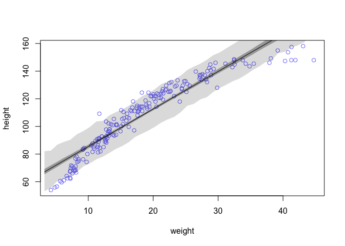

```r
plot( height ~ weight , data=d3 , col=rangi2 )
# plot the MAP line, aka the mean mu for each weight
lines( weight.seq , mu.mean )
shade( sim.HPDI , weight.seq, col = col.alpha("black",
                 0.15 ))
# plot a shaded region for 89% HPDI
shade( mu.HPDI , weight.seq, col = col.alpha("black",
                 0.30) )
```

try to plot with ggplot…

```r
plot.data <- as_tibble(cbind(weight.seq, mu.mean, t(mu.HPDI), t(sim.HPDI))) %>%
  rename(weight=weight.seq, mu.89l=`|0.89`, mu.89u=`0.89|`, sim.89l=V5, sim.89u=V6)
plot.data
```

```
## # A tibble: 43 x 6
##    weight mu.mean mu.89l mu.89u sim.89l sim.89u
##     <dbl>   <dbl>  <dbl>  <dbl>   <dbl>   <dbl>
##  1   3.25    67.1   65.3   69.3    53.1    82.1
##  2   4.25    69.8   68.1   71.9    55.7    82.6
##  3   5.25    72.5   70.9   74.5    60.5    86.9
##  4   6.25    75.2   73.8   77.3    62.1    88.8
##  5   7.25    78.0   76.5   79.7    63.7    90.4
##  6   8.25    80.7   79.4   82.4    67.1    94.3
##  7   9.25    83.4   81.9   84.7    71.1    96.7
##  8  10.3     86.1   84.8   87.5    73.3    99.6
##  9  11.3     88.8   87.6   90.1    76.2   104.
## 10  12.3     91.5   90.5   92.9    78.1   104.
## # … with 33 more rows
```

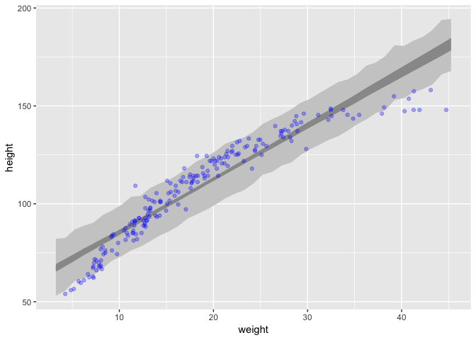

```r
plot.data %>%
  ggplot(aes(x=weight)) +
  geom_line(aes(y=mu.mean)) +
  geom_ribbon(aes(ymin=sim.89l, ymax=sim.89u), fill="gray80") +
  geom_ribbon(aes(ymin=mu.89l, ymax=mu.89u), fill="gray60") +
  geom_point(aes(y=height), data=d3,color="blue", alpha=.3) +
  ylab("height")
```

*(c) What aspects of the model fit concern you? Describe the kinds of assumptions you would change, if any, to improve the model. You don’t have to write any new code. Just explain what the model appears to be doing a bad job of, and what you hypothesize would be a better model.*

The model is trying to fit a straight line to curved data. This results in a poor fit, especially at the ends. I would fit either a polynomial or spline regression to try to correct this.

# Code from Book

```r
## R code 4.1
pos <- replicate( 1000 , sum( runif(16,-1,1) ) )

## R code 4.2
prod( 1 + runif(12,0,0.1) )
```

```
## [1] 1.910414
```

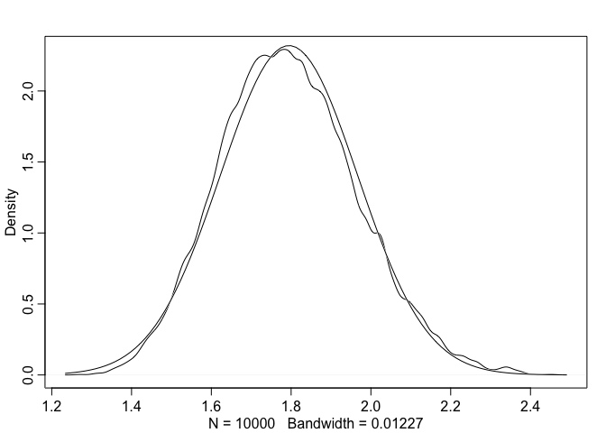

```r
## R code 4.3
growth <- replicate( 10000 , prod( 1 + runif(12,0,0.1) ) )
dens( growth , norm.comp=TRUE )
```

```r
## R code 4.4
big <- replicate( 10000 , prod( 1 + runif(12,0,0.5) ) )
small <- replicate( 10000 , prod( 1 + runif(12,0,0.01) ) )

## R code 4.5
log.big <- replicate( 10000 , log(prod(1 + runif(12,0,0.5))) )

## R code 4.6
w <- 6; n <- 9;
p_grid <- seq(from=0,to=1,length.out=100)
posterior <- dbinom(w,n,p_grid)*dunif(p_grid,0,1)
posterior <- posterior/sum(posterior)

## R code 4.7
library(rethinking)
data(Howell1)
d <- Howell1

## R code 4.8
str( d )
```

```
## 'data.frame':    544 obs. of  4 variables:
##  $ height: num  152 140 137 157 145 ...
##  $ weight: num  47.8 36.5 31.9 53 41.3 ...
##  $ age   : num  63 63 65 41 51 35 32 27 19 54 ...
##  $ male  : int  1 0 0 1 0 1 0 1 0 1 ...
```

```r
## R code 4.9
precis( d )
```

```
##               mean         sd      5.5%     94.5%     histogram
## height 138.2635963 27.6024476 81.108550 165.73500 ▁▁▁▁▁▁▁▂▁▇▇▅▁
## weight  35.6106176 14.7191782  9.360721  54.50289 ▁▂▃▂▂▂▂▅▇▇▃▂▁
## age     29.3443934 20.7468882  1.000000  66.13500     ▇▅▅▃▅▂▂▁▁
## male     0.4724265  0.4996986  0.000000   1.00000    ▇▁▁▁▁▁▁▁▁▇
```

```r
## R code 4.10
d$height
```

[output not shown]

[output cut: 63 more lines]

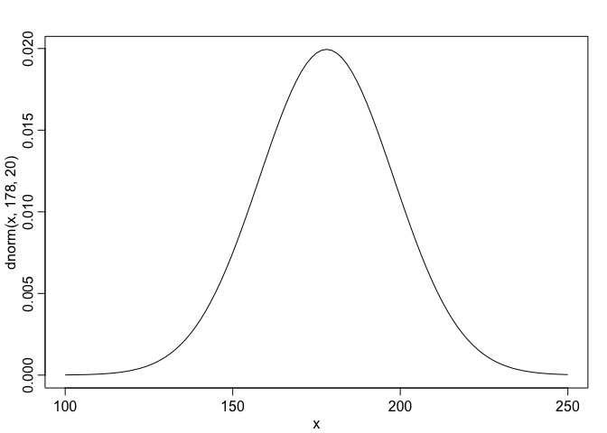

```r
## R code 4.11
d2 <- d[ d$age >= 18 , ]

## R code 4.12
curve( dnorm( x , 178 , 20 ) , from=100 , to=250 )
```

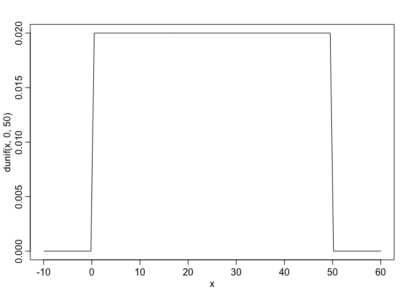

```r
## R code 4.13
curve( dunif( x , 0 , 50 ) , from=-10 , to=60 )
```

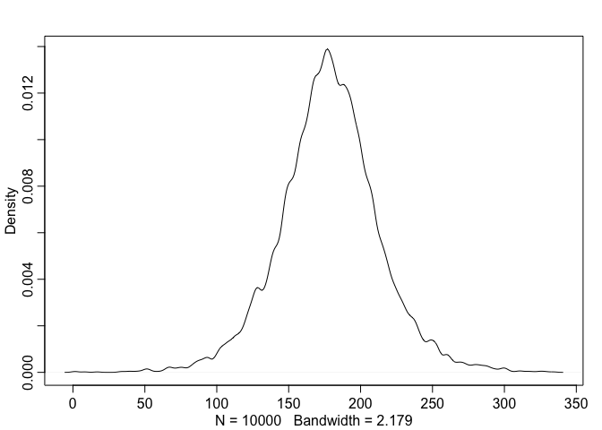

```r
## R code 4.14
sample_mu <- rnorm( 1e4 , 178 , 20 )
sample_sigma <- runif( 1e4 , 0 , 50 )
prior_h <- rnorm( 1e4 , sample_mu , sample_sigma )
dens( prior_h )
```

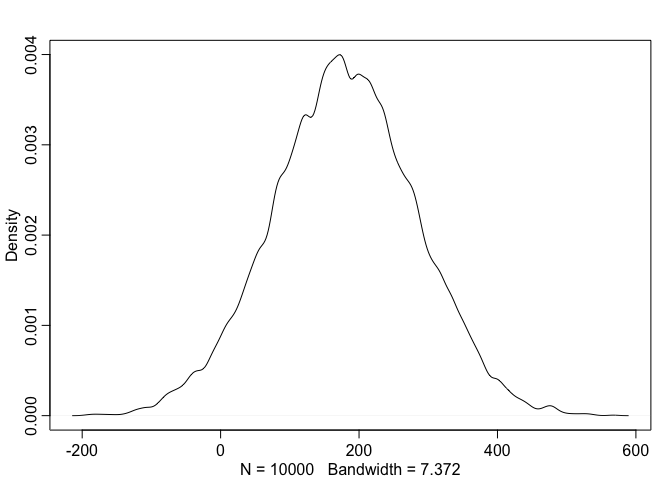

```r
## R code 4.15
sample_mu <- rnorm( 1e4 , 178 , 100 )
prior_h <- rnorm( 1e4 , sample_mu , sample_sigma )
dens( prior_h )
```

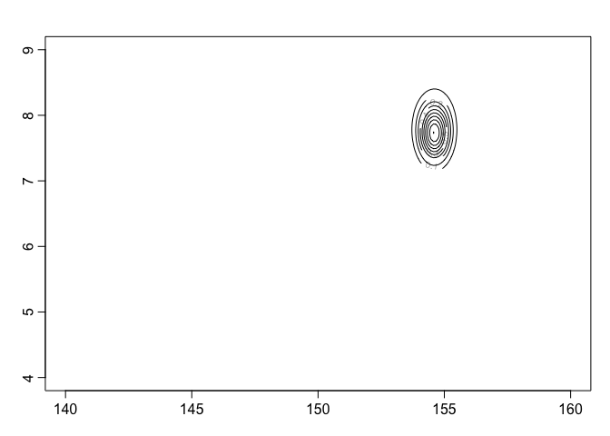

```r
## R code 4.16
mu.list <- seq( from=140, to=160 , length.out=200 )
sigma.list <- seq( from=4 , to=9 , length.out=200 )
post <- expand.grid( mu=mu.list , sigma=sigma.list )
post$LL <- sapply( 1:nrow(post) , function(i) sum( dnorm(
                d2$height ,
                mean=post$mu[i] ,
                sd=post$sigma[i] ,
                log=TRUE ) ) )
post$prod <- post$LL + dnorm( post$mu , 178 , 20 , TRUE ) +
    dunif( post$sigma , 0 , 50 , TRUE )
post$prob <- exp( post$prod - max(post$prod) )

## R code 4.17
contour_xyz( post$mu , post$sigma , post$prob )
```

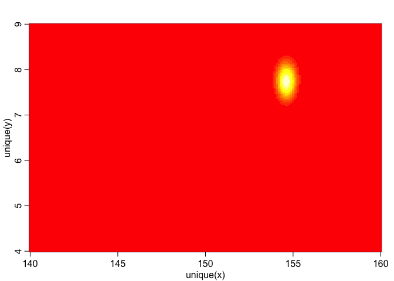

```r
## R code 4.18
image_xyz( post$mu , post$sigma , post$prob )
```

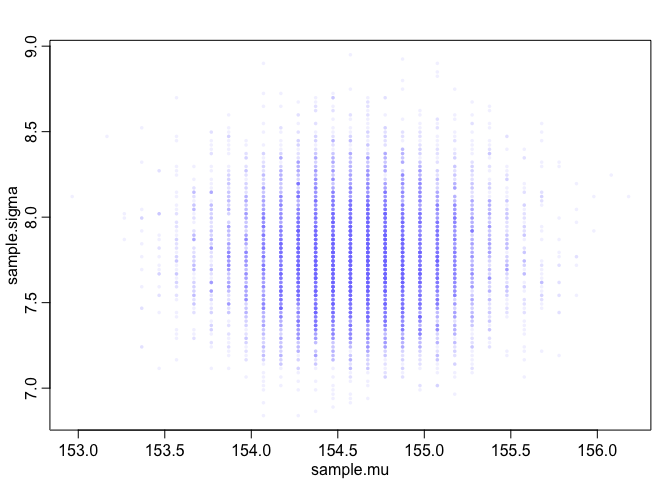

```r
## R code 4.19
sample.rows <- sample( 1:nrow(post) , size=1e4 , replace=TRUE ,
    prob=post$prob )
sample.mu <- post$mu[ sample.rows ]
sample.sigma <- post$sigma[ sample.rows ]

## R code 4.20
plot( sample.mu , sample.sigma , cex=0.5 , pch=16 , col=col.alpha(rangi2,0.1) )
```

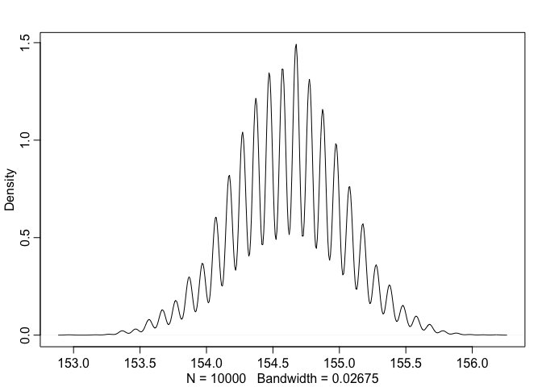

```r
## R code 4.21
dens( sample.mu )
```

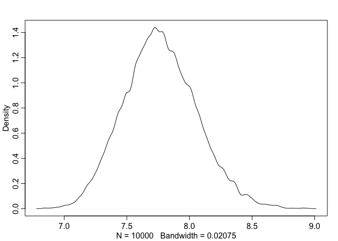

```r
dens( sample.sigma )
```

```r
## R code 4.22
HPDI( sample.mu )
```

```
##    |0.89    0.89|
## 153.8693 155.1759
```

```r
HPDI( sample.sigma )
```

```
##    |0.89    0.89|
## 7.291457 8.195980
```

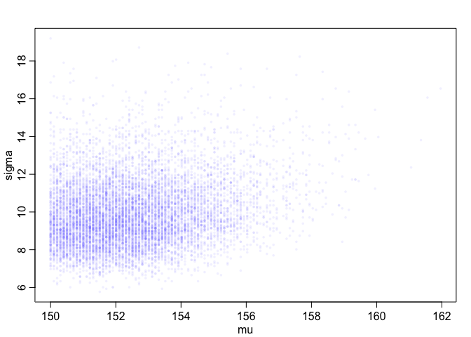

```r
## R code 4.23
d3 <- sample( d2$height , size=20 )

## R code 4.24
mu.list <- seq( from=150, to=170 , length.out=200 )
sigma.list <- seq( from=4 , to=20 , length.out=200 )
post2 <- expand.grid( mu=mu.list , sigma=sigma.list )
post2$LL <- sapply( 1:nrow(post2) , function(i)
    sum( dnorm( d3 , mean=post2$mu[i] , sd=post2$sigma[i] ,
    log=TRUE ) ) )
post2$prod <- post2$LL + dnorm( post2$mu , 178 , 20 , TRUE ) +
    dunif( post2$sigma , 0 , 50 , TRUE )
post2$prob <- exp( post2$prod - max(post2$prod) )
sample2.rows <- sample( 1:nrow(post2) , size=1e4 , replace=TRUE ,
    prob=post2$prob )
sample2.mu <- post2$mu[ sample2.rows ]
sample2.sigma <- post2$sigma[ sample2.rows ]
plot( sample2.mu , sample2.sigma , cex=0.5 ,
    col=col.alpha(rangi2,0.1) ,
    xlab="mu" , ylab="sigma" , pch=16 )
```

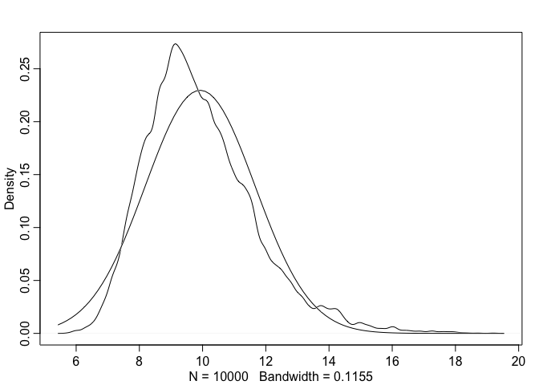

```r
## R code 4.25
dens( sample2.sigma , norm.comp=TRUE )
```

```r
## R code 4.26
library(rethinking)
data(Howell1)
d <- Howell1
d2 <- d[ d$age >= 18 , ]

## R code 4.27
flist <- alist(
    height ~ dnorm( mu , sigma ) ,
    mu ~ dnorm( 178 , 20 ) ,
    sigma ~ dunif( 0 , 50 )
)

## R code 4.28
m4.1 <- quap( flist , data=d2 )

## R code 4.29
precis( m4.1 )
```

```
##             mean        sd       5.5%      94.5%
## mu    154.606763 0.4119798 153.948340 155.265187
## sigma   7.731055 0.2913598   7.265406   8.196704
```

```r
## R code 4.30
start <- list(
    mu=mean(d2$height),
    sigma=sd(d2$height)
)
m4.1 <- quap( flist , data=d2 , start=start )

## R code 4.31
m4.2 <- quap(
    alist(
        height ~ dnorm( mu , sigma ) ,
        mu ~ dnorm( 178 , 0.1 ) ,
        sigma ~ dunif( 0 , 50 )
    ) , data=d2 )
precis( m4.2 )
```

```
##           mean        sd      5.5%    94.5%
## mu    177.8638 0.1002354 177.70356 178.0239
## sigma  24.5176 0.9289266  23.03299  26.0022
```

```r
## R code 4.32
vcov( m4.1 )
```

```
##                 mu        sigma
## mu    0.1697396109 0.0002180307
## sigma 0.0002180307 0.0849058224
```

```r
## R code 4.33
diag( vcov( m4.1 ) )
```

```
##         mu      sigma
## 0.16973961 0.08490582
```

```r
cov2cor( vcov( m4.1 ) )
```

```
##                mu       sigma
## mu    1.000000000 0.001816174
## sigma 0.001816174 1.000000000
```

```r
## R code 4.34
library(rethinking)
post <- extract.samples( m4.1 , n=1e4 )
head(post)
```

```
##         mu    sigma
## 1 154.4323 7.913822
## 2 154.5852 7.435014
## 3 154.8238 7.422743
## 4 154.6209 7.849641
## 5 154.0239 7.551737
## 6 155.1732 7.201031
```

```r
## R code 4.35
precis(post)
```

```
##            mean        sd      5.5%      94.5%     histogram
## mu    154.60018 0.4156856 153.92897 155.260859      ▁▁▁▅▇▂▁▁
## sigma   7.72872 0.2942913   7.26191   8.193346 ▁▁▁▁▂▅▇▇▃▁▁▁▁
```

```r
## R code 4.36
library(MASS)
```

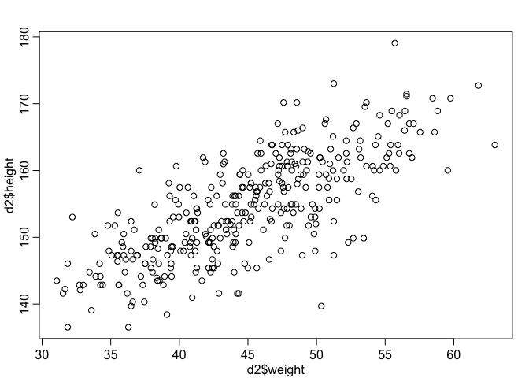

```r
post <- mvrnorm( n=1e4 , mu=coef(m4.1) , Sigma=vcov(m4.1) )

## R code 4.37
plot( d2$height ~ d2$weight )
```

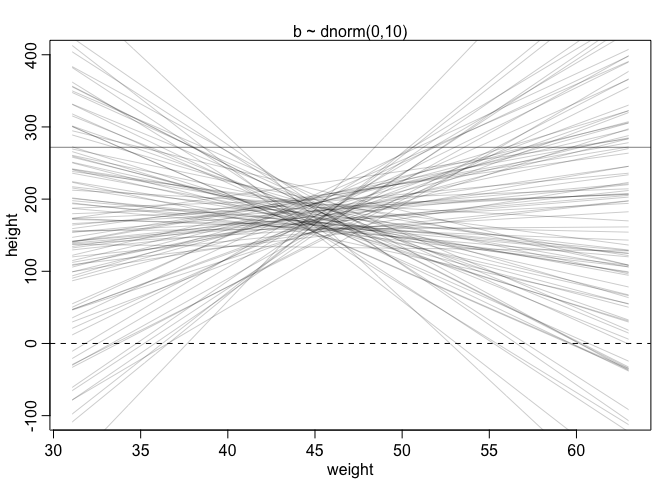

```r
## R code 4.38
set.seed(2971)
N <- 100                   # 100 lines
a <- rnorm( N , 178 , 20 )
b <- rnorm( N , 0 , 10 )

## R code 4.39
plot( NULL , xlim=range(d2$weight) , ylim=c(-100,400) ,
    xlab="weight" , ylab="height" )
abline( h=0 , lty=2 )
abline( h=272 , lty=1 , lwd=0.5 )
mtext( "b ~ dnorm(0,10)" )
xbar <- mean(d2$weight)
for ( i in 1:N ) curve( a[i] + b[i]*(x - xbar) ,
    from=min(d2$weight) , to=max(d2$weight) , add=TRUE ,
    col=col.alpha("black",0.2) )
```

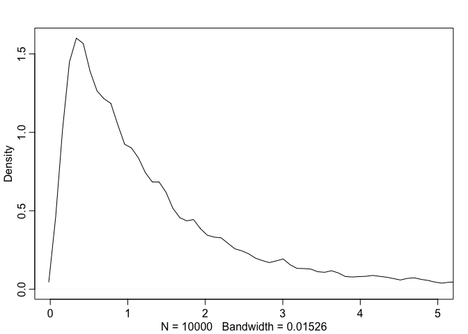

```r
## R code 4.40
b <- rlnorm( 1e4 , 0 , 1 )
dens( b , xlim=c(0,5) , adj=0.1 )
```

```r
## R code 4.41
set.seed(2971)
N <- 100                   # 100 lines
a <- rnorm( N , 178 , 20 )
b <- rlnorm( N , 0 , 1 )

## R code 4.42
# load data again, since it's a long way back
library(rethinking)
data(Howell1)
d <- Howell1
d2 <- d[ d$age >= 18 , ]

# define the average weight, x-bar
xbar <- mean(d2$weight)

# fit model
m4.3 <- quap(
    alist(
        height ~ dnorm( mu , sigma ) ,
        mu <- a + b*( weight - xbar ) ,
        a ~ dnorm( 178 , 20 ) ,
        b ~ dlnorm( 0 , 1 ) ,
        sigma ~ dunif( 0 , 50 )
    ) ,
    data=d2 )

## R code 4.43
m4.3b <- quap(
    alist(
        height ~ dnorm( mu , sigma ) ,
        mu <- a + exp(log_b)*( weight - xbar ),
        a ~ dnorm( 178 , 100 ) ,
        log_b ~ dnorm( 0 , 1 ) ,
        sigma ~ dunif( 0 , 50 )
    ) ,
    data=d2 )
```

```r
## R code 4.44
precis( m4.3 )
```

```
##              mean         sd        5.5%       94.5%
## a     154.6013671 0.27030766 154.1693633 155.0333710
## b       0.9032807 0.04192363   0.8362787   0.9702828
## sigma   5.0718809 0.19115478   4.7663786   5.3773831
```

```r
## R code 4.45
round( vcov( m4.3 ) , 3 )
```

```
##           a     b sigma
## a     0.073 0.000 0.000
## b     0.000 0.002 0.000
## sigma 0.000 0.000 0.037
```

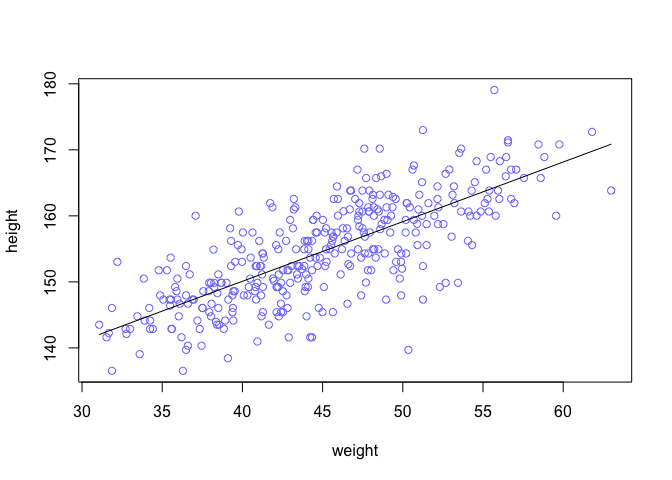

```r
## R code 4.46
plot( height ~ weight , data=d2 , col=rangi2 )
post <- extract.samples( m4.3 )
a_map <- mean(post$a)
b_map <- mean(post$b)
curve( a_map + b_map*(x - xbar) , add=TRUE )
```

```r
## R code 4.47
post <- extract.samples( m4.3 )
post[1:5,]
```

```
##          a         b    sigma
## 1 154.6673 0.9579937 5.242168
## 2 154.9493 0.9075067 4.873812
## 3 154.8834 0.9578025 5.120553
## 4 154.4967 0.8987900 5.161813
## 5 154.2916 0.8414611 4.755758
```

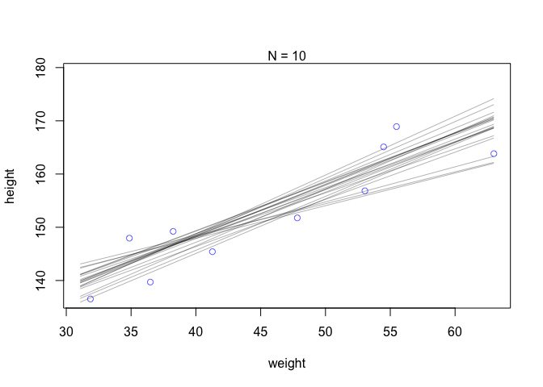

```r
## R code 4.48
N <- 10
dN <- d2[ 1:N , ]
mN <- quap(
    alist(
        height ~ dnorm( mu , sigma ) ,
        mu <- a + b*( weight - mean(weight) ) ,
        a ~ dnorm( 178 , 20 ) ,
        b ~ dlnorm( 0 , 1 ) ,
        sigma ~ dunif( 0 , 50 )
    ) , data=dN )

## R code 4.49
# extract 20 samples from the posterior
post <- extract.samples( mN , n=20 )

# display raw data and sample size
plot( dN$weight , dN$height ,
    xlim=range(d2$weight) , ylim=range(d2$height) ,
    col=rangi2 , xlab="weight" , ylab="height" )
mtext(concat("N = ",N))

# plot the lines, with transparency
for ( i in 1:20 )
    curve( post$a[i] + post$b[i]*(x-mean(dN$weight)) ,
        col=col.alpha("black",0.3) , add=TRUE )
```

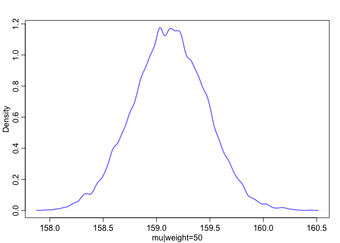

```r
## R code 4.50
post <- extract.samples( m4.3 )
mu_at_50 <- post$a + post$b * ( 50 - xbar )

## R code 4.51
dens( mu_at_50 , col=rangi2 , lwd=2 , xlab="mu|weight=50" )
```

```r
## R code 4.52
HPDI( mu_at_50 , prob=0.89 )
```

```
##    |0.89    0.89|
## 158.5710 159.6676
```

```r
## R code 4.53
mu <- link( m4.3 )
str(mu)
```

```
##  num [1:1000, 1:352] 157 158 157 157 157 ...
```

```r
## R code 4.54
# define sequence of weights to compute predictions for
# these values will be on the horizontal axis
weight.seq <- seq( from=25 , to=70 , by=1 )

# use link to compute mu
# for each sample from posterior
# and for each weight in weight.seq
mu <- link( m4.3 , data=data.frame(weight=weight.seq) )
str(mu)
```

```
##  num [1:1000, 1:46] 137 136 136 137 136 ...
```

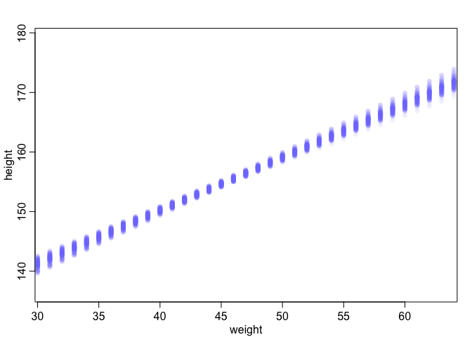

```r
## R code 4.55
# use type="n" to hide raw data
plot( height ~ weight , d2 , type="n" )

# loop over samples and plot each mu value
for ( i in 1:100 )
    points( weight.seq , mu[i,] , pch=16 , col=col.alpha(rangi2,0.1) )
```

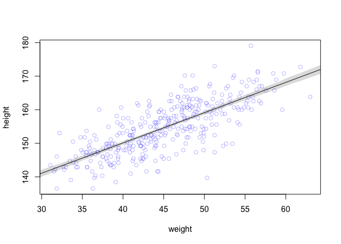

```r
## R code 4.56
# summarize the distribution of mu
mu.mean <- apply( mu , 2 , mean )
mu.HPDI <- apply( mu , 2 , HPDI , prob=0.89 )

## R code 4.57
# plot raw data
# fading out points to make line and interval more visible
plot( height ~ weight , data=d2 , col=col.alpha(rangi2,0.5) )

# plot the MAP line, aka the mean mu for each weight
lines( weight.seq , mu.mean )

# plot a shaded region for 89% HPDI
shade( mu.HPDI , weight.seq )
```

```r
## R code 4.58
post <- extract.samples(m4.3)
mu.link <- function(weight) post$a + post$b*( weight - xbar )
weight.seq <- seq( from=25 , to=70 , by=1 )
mu <- sapply( weight.seq , mu.link )
mu.mean <- apply( mu , 2 , mean )
mu.HPDI <- apply( mu , 2 , HPDI , prob=0.89 )

## R code 4.59
sim.height <- sim( m4.3 , data=list(weight=weight.seq) )
str(sim.height)
```

```
##  num [1:1000, 1:46] 142 142 126 133 134 ...
```

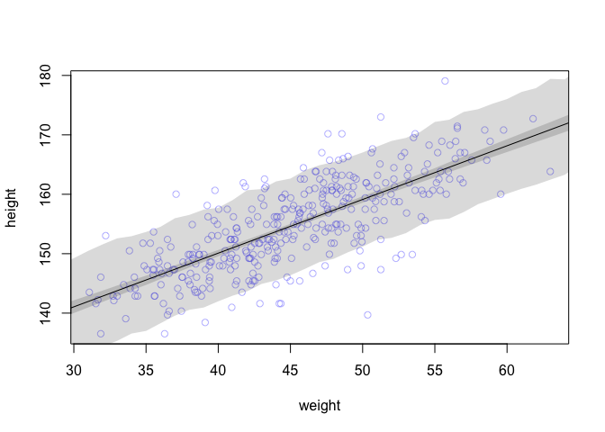

```r
## R code 4.60
height.PI <- apply( sim.height , 2 , PI , prob=0.89 )

## R code 4.61
# plot raw data
plot( height ~ weight , d2 , col=col.alpha(rangi2,0.5) )

# draw MAP line
lines( weight.seq , mu.mean )

# draw HPDI region for line
shade( mu.HPDI , weight.seq )

# draw PI region for simulated heights
shade( height.PI , weight.seq )
```

```r
## R code 4.62
sim.height <- sim( m4.3 , data=list(weight=weight.seq) , n=1e4 )
height.PI <- apply( sim.height , 2 , PI , prob=0.89 )

## R code 4.63
post <- extract.samples(m4.3)
weight.seq <- 25:70
sim.height <- sapply( weight.seq , function(weight)
    rnorm(
        n=nrow(post) ,
        mean=post$a + post$b*( weight - xbar ) ,
        sd=post$sigma ) )
height.PI <- apply( sim.height , 2 , PI , prob=0.89 )
```

```r
## R code 4.64
library(rethinking)
data(Howell1)
d <- Howell1
str(d)
```

```
## 'data.frame':    544 obs. of  4 variables:
##  $ height: num  152 140 137 157 145 ...
##  $ weight: num  47.8 36.5 31.9 53 41.3 ...
##  $ age   : num  63 63 65 41 51 35 32 27 19 54 ...
##  $ male  : int  1 0 0 1 0 1 0 1 0 1 ...
```

```r
## R code 4.65
d$weight_s <- ( d$weight - mean(d$weight) )/sd(d$weight)
d$weight_s2 <- d$weight_s^2
m4.5 <- quap(
    alist(
        height ~ dnorm( mu , sigma ) ,
        mu <- a + b1*weight_s + b2*weight_s2 ,
        a ~ dnorm( 178 , 20 ) ,
        b1 ~ dlnorm( 0 , 1 ) ,
        b2 ~ dnorm( 0 , 1 ) ,
        sigma ~ dunif( 0 , 50 )
    ) ,
    data=d )

## R code 4.66
precis( m4.5 )
```

```
##             mean        sd       5.5%      94.5%
## a     146.057415 0.3689755 145.467721 146.647109
## b1     21.733063 0.2888890  21.271363  22.194764
## b2     -7.803268 0.2741838  -8.241467  -7.365069
## sigma   5.774474 0.1764651   5.492448   6.056499
```

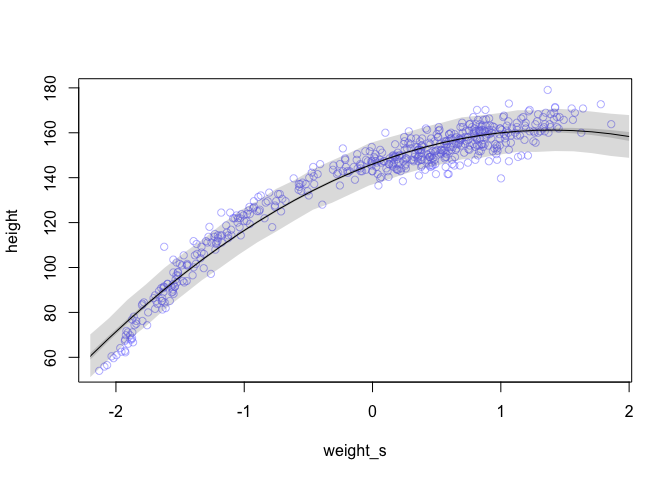

```r
## R code 4.67
weight.seq <- seq( from=-2.2 , to=2 , length.out=30 )
pred_dat <- list( weight_s=weight.seq , weight_s2=weight.seq^2 )
mu <- link( m4.5 , data=pred_dat )
mu.mean <- apply( mu , 2 , mean )
mu.PI <- apply( mu , 2 , PI , prob=0.89 )
sim.height <- sim( m4.5 , data=pred_dat )
height.PI <- apply( sim.height , 2 , PI , prob=0.89 )

## R code 4.68
plot( height ~ weight_s , d , col=col.alpha(rangi2,0.5) )
lines( weight.seq , mu.mean )
shade( mu.PI , weight.seq )
shade( height.PI , weight.seq )
```

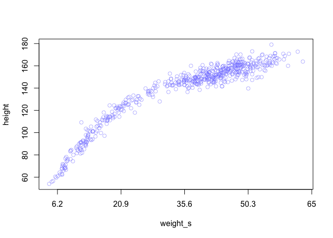

```r
## R code 4.69
d$weight_s3 <- d$weight_s^3
m4.6 <- quap(
    alist(
        height ~ dnorm( mu , sigma ) ,
        mu <- a + b1*weight_s + b2*weight_s2 + b3*weight_s3 ,
        a ~ dnorm( 178 , 20 ) ,
        b1 ~ dlnorm( 0 , 1 ) ,
        b2 ~ dnorm( 0 , 10 ) ,
        b3 ~ dnorm( 0 , 10 ) ,
        sigma ~ dunif( 0 , 50 )
    ) ,
    data=d )

## R code 4.70
plot( height ~ weight_s , d , col=col.alpha(rangi2,0.5) , xaxt="n" )

## R code 4.71
at <- c(-2,-1,0,1,2)
labels <- at*sd(d$weight) + mean(d$weight)
axis( side=1 , at=at , labels=round(labels,1) )
```

```r
## R code 4.72
library(rethinking)
data(cherry_blossoms)
d <- cherry_blossoms
precis(d)
```

```
##                   mean          sd      5.5%      94.5%       histogram
## year       1408.000000 350.8845964 867.77000 1948.23000   ▇▇▇▇▇▇▇▇▇▇▇▇▁
## doy         104.540508   6.4070362  94.43000  115.00000        ▁▂▅▇▇▃▁▁
## temp          6.141886   0.6636479   5.15000    7.29470        ▁▃▅▇▃▂▁▁
## temp_upper    7.185151   0.9929206   5.89765    8.90235 ▁▂▅▇▇▅▂▂▁▁▁▁▁▁▁
## temp_lower    5.098941   0.8503496   3.78765    6.37000 ▁▁▁▁▁▁▁▃▅▇▃▂▁▁▁
```

```r
## R code 4.73
d2 <- d[ complete.cases(d$temp) , ] # complete cases on temp
num_knots <- 15
knot_list <- quantile( d2$year , probs=seq(0,1,length.out=num_knots) )

knot_list
```

```
##        0% 7.142857% 14.28571% 21.42857% 28.57143% 35.71429% 42.85714%
##  839.0000  937.2143 1017.4286 1097.6429 1177.8571 1258.0714 1338.2857
##       50% 57.14286% 64.28571% 71.42857% 78.57143% 85.71429% 92.85714%
## 1418.5000 1498.7143 1578.9286 1659.1429 1739.3571 1819.5714 1899.7857
##      100%
## 1980.0000
```

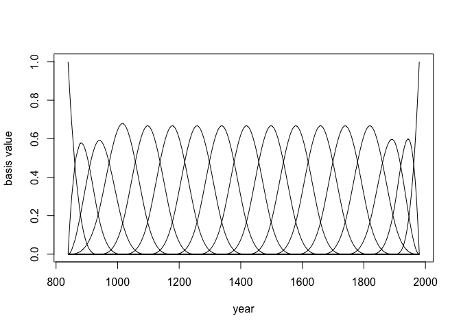

```r
## R code 4.74
library(splines)
B <- bs(d2$year,
    knots=knot_list[-c(1,num_knots)] ,
    degree=3 , intercept=TRUE )

## R code 4.75
plot( NULL , xlim=range(d2$year) , ylim=c(0,1) , xlab="year" , ylab="basis value" )
for ( i in 1:ncol(B) ) lines( d2$year , B[,i] )
```

```r
## R code 4.76
m4.7 <- quap(
    alist(
        T ~ dnorm( mu , sigma ) ,
        mu <- a + B %*% w ,
        a ~ dnorm(6,10),
        w ~ dnorm(0,1),
        sigma ~ dexp(1)
    ),
    data=list( T=d2$temp , B=B ) ,
    start=list( w=rep( 0 , ncol(B) ) ) )
```

```r
## R code 4.77
post <- extract.samples(m4.7)
str(post)
```

```
## List of 3
##  $ a    : num [1:10000] 6.29 6.08 6.77 6.14 6.73 ...
##  $ sigma: num [1:10000] 0.346 0.344 0.345 0.341 0.337 ...
##  $ w    : num [1:10000, 1:17] 0.0233 0.675 -0.3895 0.3515 -0.405 ...
##  - attr(*, "source")= chr "quap posterior: 10000 samples from m4.7"
```

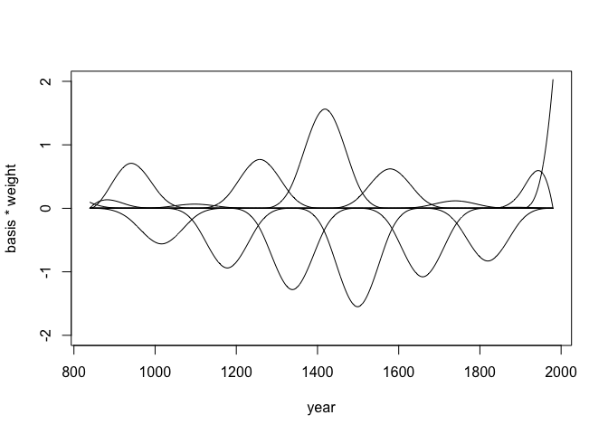

```r
w <- apply( post$w , 2 , mean )
plot( NULL , xlim=range(d2$year) , ylim=c(-2,2) ,
    xlab="year" , ylab="basis * weight" )
for ( i in 1:ncol(B) ) lines( d2$year , w[i]*B[,i] )
```

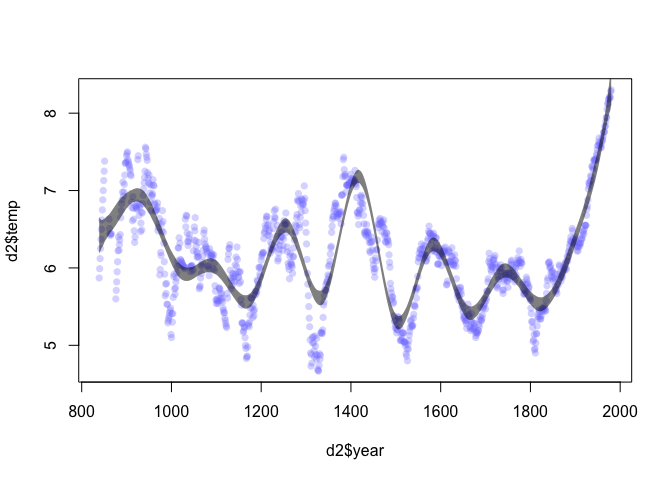

```r
## R code 4.78
mu <- link( m4.7 )
mu_PI <- apply(mu,2,PI,0.97)
plot( d2$year , d2$temp , col=col.alpha(rangi2,0.3) , pch=16 )
shade( mu_PI , d2$year , col=col.alpha("black",0.5) )
```

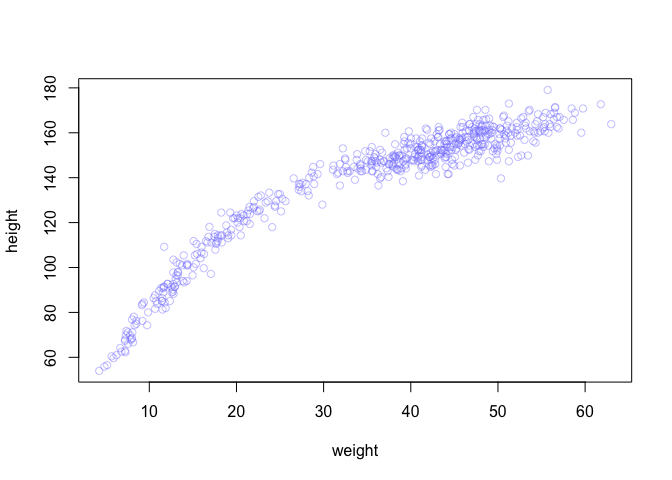

```r
## R code 4.79
plot( height ~ weight , data=Howell1 ,
    col=col.alpha(rangi2,0.4) )
```